# IODS course project

#### Visual presentation of the relationship between alcohol use and the tendency to go out with friends

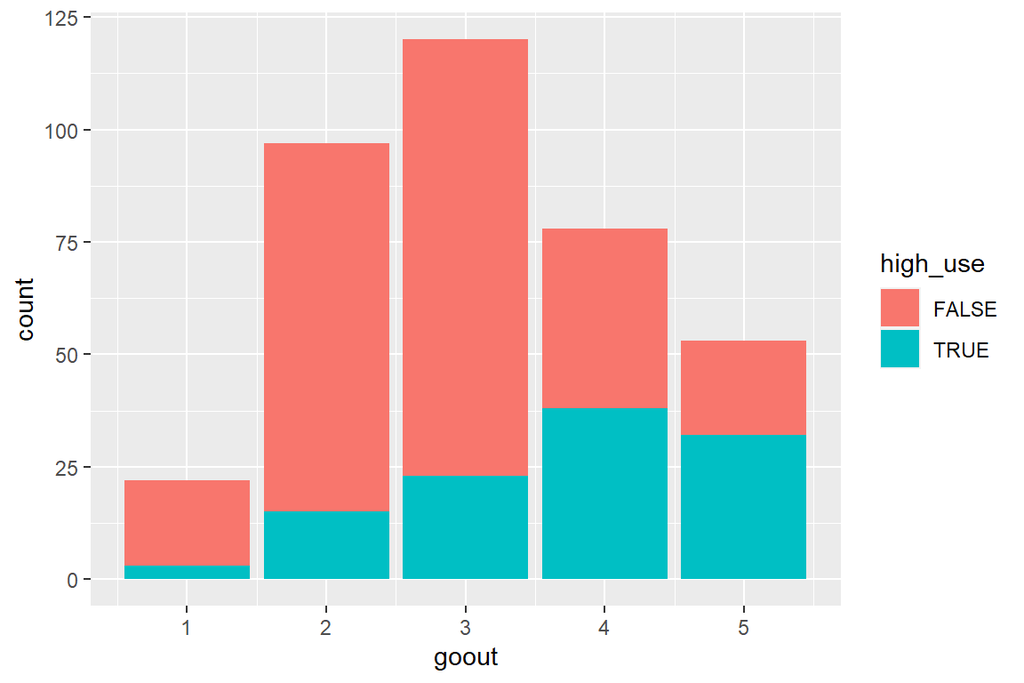

```r
# Plotting a bar plot
plot3 <- ggplot(data = alc, aes(x = goout, fill = high_use))
plot3 + geom_bar()
```

As expected, the proportion of students using high amounts of alcohol steadily rises as the going-out-with-friends tendency increases.

#### Visual presentation of the relationship between alcohol use and the quality of family relationships

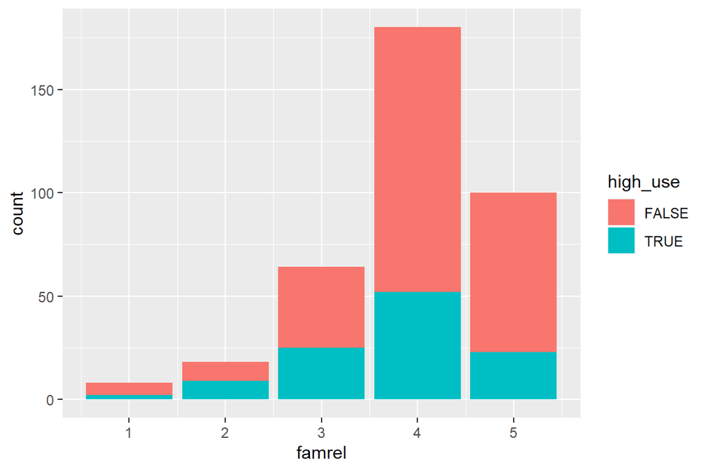

```r
# Plotting a bar plot
plot4 <- ggplot(data = alc, aes(x = famrel, fill = high_use))
plot4 + geom_bar()
```

Again, as expected the trend here seems to be that as the quality of family relationships increases, the high alcohol use decreases.

All in all, the visual results are mainly in line with my hypothesis. Let’s see what regression analyses have to say.

### Logistic regression model

```r
# Fitting the model
model1 <- glm(high_use ~ higher + goout + absences + famrel, data = alc, family = "binomial")

summary(model1)
```

```
##
## Call:
## glm(formula = high_use ~ higher + goout + absences + famrel,
##     family = "binomial", data = alc)
##
## Coefficients:
##             Estimate Std. Error z value Pr(>|z|)
## (Intercept) -1.50075    0.85280  -1.760  0.07844 .
## higheryes   -0.79489    0.58003  -1.370  0.17055
## goout        0.76184    0.12154   6.268 3.65e-10 ***
## absences     0.07102    0.02216   3.205  0.00135 **
## famrel      -0.37135    0.13711  -2.708  0.00676 **
## ---
## Signif. codes:  0 '***' 0.001 '**' 0.01 '*' 0.05 '.' 0.1 ' ' 1
##
## (Dispersion parameter for binomial family taken to be 1)
##
##     Null deviance: 452.04  on 369  degrees of freedom
## Residual deviance: 380.90  on 365  degrees of freedom
## AIC: 390.9
##
## Number of Fisher Scoring iterations: 4
```

The coefficients can be thought as odds ratios between a unit change of the variable vs no change. However, they have to be exponentiated first to get the odds ratios.

Here, in case of the ‘higher’ variable, we can only see the coefficient for wanting to get a higher education. This is because the model compares it to the option of not wanting to get a higher education (not seen here, the coefficient for it is actually the intercept).

```r
# Lets get the odds ratios by exponentiating the coefficients

OR <- coef(model1) %>% exp()
OR
```

```
## (Intercept)   higheryes       goout    absences      famrel
##   0.2229634   0.4516311   2.1422037   1.0736039   0.6897992
```

```r
# Let's get the confidence intervals for the ORs
CI <- confint(model1) %>% exp()
# Create a table with ORs and CIs
cbind(OR, CI)
```

```
##                    OR     2.5 %    97.5 %
## (Intercept) 0.2229634 0.0406289 1.1691823
## higheryes   0.4516311 0.1399596 1.4017024
## goout       2.1422037 1.6984776 2.7382000
## absences    1.0736039 1.0296054 1.1243329
## famrel      0.6897992 0.5255693 0.9014479
```

Other coefficients are signficant, and it seems that going out with friends and absences are associated with higher alcohol consumption (ORs are over 1 and CIs don’t cross under 1). For example, OR for goout is 2.14, which means one unit increase in the goout range(1-5), the odds of using high amounts of alcohol increases by 114% ((2.14-1)x100). Additionally, famrel is negatively associated with high_use: OR is 0.69, so the odds of using high amounts of alcohol decreases by 31% ((0.69-1)x100) with one unit increase in the quality of family relationships scale (1-5).

### Improved logistic regression model

```r
# Fitting another model with only statistically significant explanatory variables
model2 <- glm(high_use ~ goout + absences + famrel, data = alc, family = "binomial")

summary(model2)
```

```
##
## Call:
## glm(formula = high_use ~ goout + absences + famrel, family = "binomial",
##     data = alc)
##
## Coefficients:
##             Estimate Std. Error z value Pr(>|z|)
## (Intercept) -2.30049    0.63469  -3.625 0.000289 ***
## goout        0.77213    0.12083   6.390 1.66e-10 ***
## absences     0.07360    0.02187   3.365 0.000765 ***
## famrel      -0.37221    0.13641  -2.728 0.006362 **
## ---
## Signif. codes:  0 '***' 0.001 '**' 0.01 '*' 0.05 '.' 0.1 ' ' 1
##
## (Dispersion parameter for binomial family taken to be 1)
##
##     Null deviance: 452.04  on 369  degrees of freedom
## Residual deviance: 382.79  on 366  degrees of freedom
## AIC: 390.79
##
## Number of Fisher Scoring iterations: 4
```

```r
# Calculating the probabilities of high alcohol use according to the model
probabilities <- predict(model2, type = "response")

# Adding the probabilities to the data set
alc <- mutate(alc, probability = probabilities)

# Adding a prediction column, where probability of over 0.5 means that the model predicts that the student uses high amounts of alcohol
alc <- mutate(alc, prediction = probability > 0.5)

# Create 2x2 cross tabulation of predictions versus the actual values
table(high_use = alc$high_use, prediction = alc$prediction)
```

```
##         prediction
## high_use FALSE TRUE
##    FALSE   236   23
##    TRUE     67   44
```

```r
# Create a function to calculate the proportion of inaccurately predicted values
loss_func <- function(class, prob) {
  n_wrong <- abs(class - prob) > 0.5
  mean(n_wrong)
}

# Calculate the proportion
loss_func(class = alc$high_use, prob = alc$probability)
```

```
## [1] 0.2432432
```

So the proportion of inaccurate predictions is 24%. This seems to be quite a small error, since I would guess that alcohol consumption is a very complex behaviour with multiple explanatory variables, and I wouldn’t have though that 3 variables would be this good at predicting it. However, the threshold for high use is quite arbitruary and with a different one the result would be different as well.